# Statistics: The Science of Decisions Project Instructions

### Background Information

In a Stroop task, participants are presented with a list of words, with each word displayed in a color of ink. The participant’s task is to say out loud the color of the ink in which the word is printed. The task has two conditions: a congruent words condition, and an incongruent words condition. In the congruent words condition, the words being displayed are color words whose names match the colors in which they are printed: for example RED, BLUE. In the incongruent words condition, the words displayed are color words whose names do not match the colors in which they are printed: for example PURPLE, ORANGE. In each case, we measure the time it takes to name the ink colors in equally sized lists. Each participant will go through and record a time from each condition.

### Questions For Investigation

As a general note, be sure to keep a record of any resources that you use or refer to in the creation of your project. You will need to report your sources as part of the project submission.

1. What is our independent variable? What is our dependent variable?

*Answer:*

> The independent variable is the congruent words and incongruent words.  
> The depedent variable is the time it takes to name the ink colors.

2. What is an appropriate set of hypotheses for this task? What kind of statistical test do you expect to perform? Justify your choices.

*Answer:*

> We have two word sets for test: congrent words set and incongruent words set. Both sets have the equal number of words. We need to find out that for the experimental population group, if the same person in group will have the same response time to the two tested word sets. We are using a sample in order to make inferences about the population, that is unknown, to find whether there is a difference between congruent and incongruent means in the population. We are using the sample to infer something about the population.

> The idea of hypothesis testing and statistical inference is that we have limited data, samples(generally denoted by X), and from that limited data, we are trying to infer something about the population (generally denoted by U) we don't know about. With our test we are trying to assess whether the sample means are different because the two populations and population means are different or just by chance. Therefore our hypothesis should be concerned with $\mu_C$ and $\mu_I$, respectively the congruent and incongruent population response time means.

> Another important aspect of the statistical test - is to specify whether the test is a dependent or an independent test based on the way the experiment is being conducted. Since we conduct the congruent test and incongruent test on the same person, with one test after the other, the test may influence the result of other test. Therefore our current test is dependent test. In future we try to conduct two independent test on different samples (person), so no one will take the two test together.

> The appropriate set of hyposthesis is composed by Null hypothesis and Alternative hypothesis.

> *Null Hypothesis $H_0$*: There is no difference in population means of response time under incongruent and congruent scenarios, which can be mathematically represented as $$\mu_C = \mu_I.$$

> *The alternative $H_A$*: Hypothesis is the response time for the same group people on congrent words set and in congruent word set are different, represented as $$\mu_C \neq \mu_I.$$

> We are proposed to use t-test instead of a z-test for example. There are a few reasons for our choice.
> 1. Our sample size in data sets is less than 30 smaples.
> 2. We don't know the distributions of the population.
> 3. We don't know the population standard deviation.

> So it is better to choose t-test for our data set.

Now it’s your chance to try out the Stroop task for yourself. Go to [this link](https://www.google.com/url?q=https://faculty.washington.edu/chudler/java/ready.html&sa=D&ust=1501170814608000&usg=AFQjCNEB5q9DABPxMRgJX2RISYcM9ekgWg), which has a Java-based applet for performing the Stroop task. Record the times that you received on the task (you do not need to submit your times to the site.) Now, download [this dataset](https://drive.google.com/file/d/0B9Yf01UaIbUgQXpYb2NhZ29yX1U/view?usp=sharing) which contains results from a number of participants in the task. Each row of the dataset contains the performance for one participant, with the first number their results on the congruent task and the second number their performance on the incongruent task.

3. Report some descriptive statistics regarding this dataset. Include at least one measure of central tendency and at least one measure of variability.

**Answer:**

> The measure of central tendency is the average of data sets, or called the mean of data sets. The measure of variability of data sets could be variance, standard deviation, or standard error. We first calculate the measurement on the two experimental data sets. The mean of congrent words experimental data sets is $\overline{X_C} = 14.051125$, the standard deviation is $S_C =3.559357958$; The mean of incongrent words experimental data sets is $\overline{X_I} =22.01591667$, the standard deviation is $S_I = 4.797057122$; The sample size in each experiement is $n_C = n_I =24$.

4. Provide one or two visualizations that show the distribution of the sample data. Write one or two sentences noting what you observe about the plot or plots.

```python
import pandas as pd

path = 'stroopdata.csv'
df = pd.read_csv(path)
```

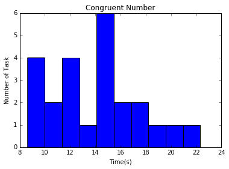

```python
%pylab inline

import matplotlib.pyplot as plt

Congruent_data = df['Congruent']
plt.hist(Congruent_data, bins=10)
plt.xlabel("Time(s)")
plt.ylabel("Number of Task")
plt.title("Congruent Number")
plt.show()
```

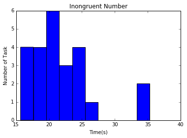

```python
Incongruent_data = df['Incongruent']
plt.hist(Incongruent_data, bins = 10)
plt.xlabel("Time(s)")
plt.ylabel("Number of Task")
plt.title("Inongruent Number")
plt.show()
```

5. Now, perform the statistical test and report your results. What is your confidence level and your critical statistic value? Do you reject the null hypothesis or fail to reject it? Come to a conclusion in terms of the experiment task. Did the results match up with your expectations?

**Answer:**

> The standard deviation difference is $S_{CI} = 4.86482691$; The t-statistic value is $$t = \frac{\overline{X_C} - \overline{X_I}}{\frac{S_{CI}}{\sqrt{n}}} = -8.02092.$$

> We then set the confidence interval of our experiment is $95\%$, and the $\alpha = 0.05$. The freedom degree $n - 1 = 23$. After checking the t-table, we find the t critical statistic value with is around $t_{critical} = -2.06865761$ for two tail test.

> Finally, we compare the t-statistic value with the t-critical value. Since $t = -8.02092 < t_{critical} = -2.06865761$, we reject the Null hypothesis $H_0$ and accept the alternative hypothesis $H_A$, that is the response time on congrent words set and congruent words set are different.

> To conclude the experiment, we are sure that the response time on congrent words set is lower than the congruent words set in $95\%$ confidency. This result match up my own experiment result. My own test on congruent words cost 15.745 seconds, while the incongruent words cost 43.736 seconds.

6. Optional: What do you think is responsible for the effects observed? Can you think of an alternative or similar task that would result in a similar effect? Some research about the problem will be helpful for thinking about these two questions!